# R-scripts, statistical analyses, results and plots.

Results from auxin inhibition study.

Bishwa K. Giri

Sept 15th, 2018

### Step 01: Set the required path (only if requred)

```r
# find the working directory
getwd()
```

```
## [1] "/home/priyanka/Dropbox/DataAnalyses/LyrataPhotoDataAnalyses"
```

```r
# ** Change path if need be.
setwd("/home/priyanka/Dropbox/DataAnalyses/LyrataPhotoDataAnalyses")
getwd()
```

```
## [1] "/home/priyanka/Dropbox/DataAnalyses/LyrataPhotoDataAnalyses"
```

```r
list.files()  # read available files and folders
```

```
##  [1] "AlyAuxinTreatmentDataAnalyses.html"
##  [2] "AlyAuxinTreatmentDataAnalyses.pdf"
##  [3] "AlyAuxinTreatmentDataAnalyses.R"
##  [4] "AlyAuxinTreatmentDataAnalyses.spin.R"
##  [5] "AlyAuxinTreatmentDataAnalyses.spin.Rmd"
##  [6] "BkGiriResearchPlots"
##  [7] "DiameterAndTreatmentData.txt"
##  [8] "DLRscripts2015.R"
##  [9] "M-14-8-J_9-18-2017.jpg"
## [10] "notebook"
## [11] "PreviousPhenotypeDataAnalysesResearch"
## [12] "rscriptsandresults"
## [13] "ScriptsForRmarkdown.txt"
## [14] "subMeans.txt"
## [15] "testScript.html"
## [16] "testScript.log"
## [17] "testScript.R"
## [18] "testScript.tex"
## [19] "TraitsData"
```

### Step 02: Read the input data

**The input files are provided in folder named “TraitsData”**  
**in the link :** https://github.com/everestial/AuxinInhibitionResultsDataAnalyses  
In our research the data was collected biweekly by taking pictures vertically.  
The photos of the plant included an inch scale on the side along with it’s ID labelled with it’s “Treatment”.

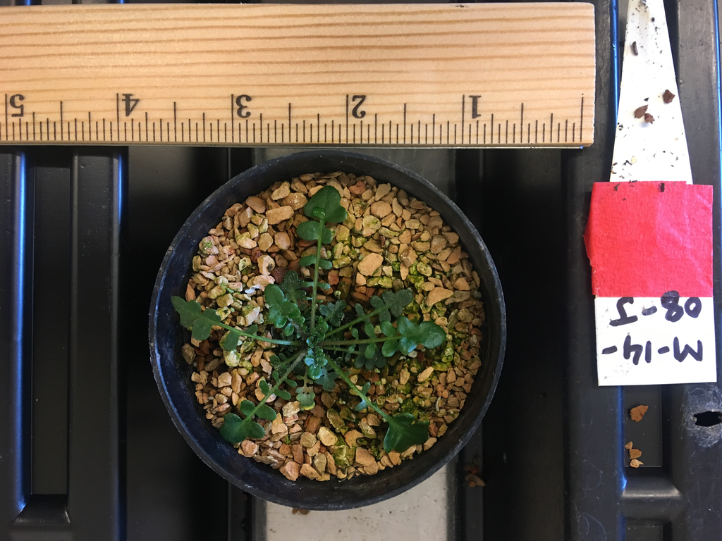

```r
# Now, read the data from month (from Sep 2017 to March 2018).
DataFromSep <- readxl::read_xlsx("TraitsData/09_18_2017_Data.xlsx", col_names = TRUE)
head(DataFromSep)
```

```
## # A tibble: 6 x 15
##   Date   Plan… Fami… `Dia… Lat_… Infl… Leaf… Tric… Trea… Trea… Popu… Bolt…
##   <chr>  <chr> <dbl> <chr> <chr> <chr> <chr> <chr> <chr> <chr> <chr> <chr>
## 1 09_18… M-14…  8.00 2.2   0     0     3     2     Auxin Aux_… My    0
## 2 09_18… M-14…  8.00 2.5   0     0     3     2     Auxin Aux_… My    0
## 3 09_18… M-14…  8.00 2.6   0     0     3     2     Cont… DMSO  My    0
## 4 09_18… M-14…  8.00 1.7   0     0     3     3     Cont… Water My    0
## 5 09_18… M-14…  8.00 1.5   1     1     3     2     Auxin Aux_… My    1
## 6 09_18… M-14…  8.00 3     0     0     3     1     Auxin Aux_… My    0
## # ... with 3 more variables: Flowering <chr>, Remarks_01 <chr>,
## #   Remarks_02 <chr>
```

```r
DataFromDec <- readxl::read_xlsx("TraitsData/12_18_2017_Data.xlsx", col_names = TRUE)
head(DataFromDec)
```

```
## # A tibble: 6 x 15
##   Date   Plan… Fami… `Dia… Lat_… Infl… Leaf… Tric… Trea… Trea… Popu… Bolt…
##   <chr>  <chr> <dbl> <chr> <chr> <chr> <chr> <chr> <chr> <chr> <chr> <chr>
## 1 12_18… M-14…  8.00 NA    NA    NA    NA    NA    Auxin Aux_… My    NA
## 2 12_18… M-14…  8.00 3.7   2     1     2     1     Auxin Aux_… My    1
## 3 12_18… M-14…  8.00 NA    NA    NA    NA    NA    Cont… DMSO  My    NA
## 4 12_18… M-14…  8.00 4.2   2     4     3     1     Cont… Water My    1
## 5 12_18… M-14…  8.00 2.6   3     7     2     2     Auxin Aux_… My    1
## 6 12_18… M-14…  8.00 3.7   3     0     1     1     Auxin Aux_… My    0
## # ... with 3 more variables: Flowering <chr>, Remarks_01 <chr>,
## #   Remarks_02 <chr>
```

```r
DataFromMar <- readxl::read_xlsx("TraitsData/03_28_2018_Data.xlsx", col_names = TRUE)
head(DataFromMar)
```

```
## # A tibble: 6 x 15
##   Date   Plan… Fami… `Dia… Lat_… Infl… Leaf… Tric… Trea… Trea… Popu… Bolt…
##   <chr>  <chr> <dbl> <chr> <chr> <chr> <chr> <chr> <chr> <chr> <chr> <chr>
## 1 03_28… M-14…  8.00 NA    NA    NA    NA    NA    Auxin Aux_… My    NA
## 2 03_28… M-14…  8.00 4.2   3     3     2     2     Auxin Aux_… My    1
## 3 03_28… M-14…  8.00 NA    NA    NA    NA    NA    Cont… DMSO  My    NA
## 4 03_28… M-14…  8.00 3.6   3     5     3     1     Cont… Water My    1
## 5 03_28… M-14…  8.00 3.4   3     6     3     2     Auxin Aux_… My    1
## 6 03_28… M-14…  8.00 4.6   3     0     2     1     Auxin Aux_… My    0
## # ... with 3 more variables: Flowering <chr>, Remarks_01 <chr>,
## #   Remarks_02 <lgl>
```

#### Step 02 - A: Rename/Adjust column names

Here, we will create unique names of each columns for each dataframe  
But, some column names will be kept common which will help in merging the data  
**Process :**  
* add unique (month name) suffix to each dataframe “header”  
* reset the names like “plant ID”, “treatment” and “population” as they are

```r
colnames(DataFromSep) <- paste(colnames(DataFromSep), "Sep", sep = ".")
  # set the names of some columns back to original
colnames(DataFromSep)[colnames(DataFromSep)=="Plant_ID.Sep"] <- "Plant_ID"
colnames(DataFromSep)[colnames(DataFromSep)=="Treatment.Sep"] <- "Treatment"
colnames(DataFromSep)[colnames(DataFromSep)=="Population.Sep"] <- "Population"
colnames(DataFromSep)[colnames(DataFromSep)=="Family.Sep"] <- "Family"
colnames(DataFromSep)[colnames(DataFromSep)=="TreatmentLevel.Sep"] <- "TreatmentLevel"

colnames(DataFromDec) <- paste(colnames(DataFromDec), "Dec", sep = ".")
  # set the names of some columns back to original
colnames(DataFromDec)[colnames(DataFromDec)=="Plant_ID.Dec"] <- "Plant_ID"
colnames(DataFromDec)[colnames(DataFromDec)=="Treatment.Dec"] <- "Treatment"
colnames(DataFromDec)[colnames(DataFromDec)=="Population.Dec"] <- "Population"
colnames(DataFromDec)[colnames(DataFromDec)=="Family.Dec"] <- "Family"
colnames(DataFromDec)[colnames(DataFromDec)=="TreatmentLevel.Dec"] <- "TreatmentLevel"

colnames(DataFromMar) <- paste(colnames(DataFromMar), "Mar", sep = ".")
  # set the names of some columns back to original
colnames(DataFromMar)[colnames(DataFromMar)=="Plant_ID.Mar"] <- "Plant_ID"
colnames(DataFromMar)[colnames(DataFromMar)=="Treatment.Mar"] <- "Treatment"
colnames(DataFromMar)[colnames(DataFromMar)=="Population.Mar"] <- "Population"
colnames(DataFromMar)[colnames(DataFromMar)=="Family.Mar"] <- "Family"
colnames(DataFromMar)[colnames(DataFromMar)=="TreatmentLevel.Mar"] <- "TreatmentLevel"

head(DataFromSep)
```

```
## # A tibble: 6 x 15
##   Date.… Plan… Fami… `Dia… Lat_… Infl… Leaf… Tric… Trea… Trea… Popu… Bolt…
##   <chr>  <chr> <dbl> <chr> <chr> <chr> <chr> <chr> <chr> <chr> <chr> <chr>
## 1 09_18… M-14…  8.00 2.2   0     0     3     2     Auxin Aux_… My    0
## 2 09_18… M-14…  8.00 2.5   0     0     3     2     Auxin Aux_… My    0
## 3 09_18… M-14…  8.00 2.6   0     0     3     2     Cont… DMSO  My    0
## 4 09_18… M-14…  8.00 1.7   0     0     3     3     Cont… Water My    0
## 5 09_18… M-14…  8.00 1.5   1     1     3     2     Auxin Aux_… My    1
## 6 09_18… M-14…  8.00 3     0     0     3     1     Auxin Aux_… My    0
## # ... with 3 more variables: Flowering.Sep <chr>, Remarks_01.Sep <chr>,
## #   Remarks_02.Sep <chr>
```

```r
## **use if need be: this renaming can also be done with library(data.table)
#library(data.table)
#data.table::setnames(DataFromDec, old = c("Plant_ID.Dec", "Treatment.Dec"),
         #new = c("Plant_ID", "Treatment"))
```

### Step 03: Merge dataframes

```r
## ** Use if need be: We can merge only two dataframes one at a time
#merged.Sept.Dec <- merge(DataFromSept, DataFromDec,
                             #by=c("Plant_ID", "Treatment", "Population"), all = TRUE)
```

**Or we can merge multiple dataframes using a “Reduce - Merge” function.**

```r
merged.Sep.Dec.Mar = Reduce(function(x, y)
  merge(x, y, by=c("Plant_ID", "Population", "Family", "TreatmentLevel", "Treatment"),
        all = TRUE), list(DataFromSep, DataFromDec, DataFromMar))
head(merged.Sep.Dec.Mar)
```

```
##    Plant_ID Population Family TreatmentLevel Treatment   Date.Sep
## 1 M-14-08-A         My      8          Auxin  Aux_Drop 09_18_2017
## 2 M-14-08-B         My      8          Auxin Aux_Spray 09_18_2017
## 3 M-14-08-C         My      8        Control      DMSO 09_18_2017
## 4 M-14-08-D         My      8        Control     Water 09_18_2017
## 5 M-14-08-E         My      8          Auxin  Aux_Drop 09_18_2017
## 6 M-14-08-F         My      8          Auxin Aux_Spray 09_18_2017
##   Diameter(inches).Sep Lat_Shoot_R.Sep Inflorescence.Sep Leaf_Shape.Sep
## 1                  2.2               0                 0              3
## 2                  2.5               0                 0              3
## 3                  2.6               0                 0              3
## 4                  1.7               0                 0              3
## 5                  1.5               1                 1              3
## 6                    3               0                 0              3
##   Trichomes_int.Sep Bolting.Sep Flowering.Sep Remarks_01.Sep
```

[output cut: 55 more lines]

```r
## convert the "NA" strings as empty NA values
merged.Sep.Dec.Mar[merged.Sep.Dec.Mar == "NA"] <- NA
```

**Remove not-required column names by matching “header names”.**  
**such as “Date”, “Remarks”, etc.**  
This helps to keep the memory low.

```r
# find the columns to drop (i.e they are not required any more in this data analyses)
# this code find the column by matching the pattern
dropcols = unique(grep(paste(c("Date", "Remarks"), collapse="|"),
                       colnames(merged.Sep.Dec.Mar), value=TRUE))
dropcols
```

```
## [1] "Date.Sep"       "Remarks_01.Sep" "Remarks_02.Sep" "Date.Dec"
## [5] "Remarks_01.Dec" "Remarks_02.Dec" "Date.Mar"       "Remarks_01.Mar"
## [9] "Remarks_02.Mar"
```

```r
# drop the columns
merged.Sep.Dec.Mar = merged.Sep.Dec.Mar[, !(names(merged.Sep.Dec.Mar) %in% dropcols)]
head(merged.Sep.Dec.Mar)
```

```
##    Plant_ID Population Family TreatmentLevel Treatment
## 1 M-14-08-A         My      8          Auxin  Aux_Drop
## 2 M-14-08-B         My      8          Auxin Aux_Spray
## 3 M-14-08-C         My      8        Control      DMSO
## 4 M-14-08-D         My      8        Control     Water
## 5 M-14-08-E         My      8          Auxin  Aux_Drop
## 6 M-14-08-F         My      8          Auxin Aux_Spray
##   Diameter(inches).Sep Lat_Shoot_R.Sep Inflorescence.Sep Leaf_Shape.Sep
## 1                  2.2               0                 0              3
## 2                  2.5               0                 0              3
## 3                  2.6               0                 0              3
## 4                  1.7               0                 0              3
## 5                  1.5               1                 1              3
## 6                    3               0                 0              3
##   Trichomes_int.Sep Bolting.Sep Flowering.Sep Diameter(inches).Dec
```

[output cut: 34 more lines]

```r
# **use if need be : use subset to select specific columns
#merged.Sept.Dec.Mar.selected = subset(merged.Sept.Dec.Mar, select = c(dropcols))
```

### Step 04: Assign proper datatype to each column

**It is important to assign proper datatype to each column**  
**Reading from excel file store most of the datatype as “character”**  
**We will convert most datatypes to “double” and columns like “Population”, “family”,** **“TreatmentLevel”, “Treatment” to “factor type”.**

```r
## find the column names for which we want to convert the data types
ChangeToDouble = unique(grep(paste(c("Diameter", "Lat_Shoot", "Inflores",
                                     "Leaf_Shape", "Trichomes", "Bolting", "Flower"), collapse="|"),
                       colnames(merged.Sep.Dec.Mar), value=TRUE))
# see which columns will be changed to "double" type
ChangeToDouble
```

```
##  [1] "Diameter(inches).Sep" "Lat_Shoot_R.Sep"      "Inflorescence.Sep"
##  [4] "Leaf_Shape.Sep"       "Trichomes_int.Sep"    "Bolting.Sep"
##  [7] "Flowering.Sep"        "Diameter(inches).Dec" "Lat_Shoot_R.Dec"
## [10] "Inflorescence.Dec"    "Leaf_Shape.Dec"       "Trichomes_int.Dec"
## [13] "Bolting.Dec"          "Flowering.Dec"        "Diameter(inches).Mar"
## [16] "Lat_Shoot_R.Mar"      "Inflorescence.Mar"    "Leaf_Shape.Mar"
## [19] "Trichomes_int.Mar"    "Bolting.Mar"          "Flowering.Mar"
```

```r
ChangeToFactor = unique(grep(paste(c( "Family", "Population", "Treatment"), collapse="|"),
                             colnames(merged.Sep.Dec.Mar), value=TRUE))
# see which columns will be changed to "factor" type
ChangeToFactor
```

```
## [1] "Population"     "Family"         "TreatmentLevel" "Treatment"
```

```r
## Change datatype of the columns
# change required columns to "double" type
merged.Sep.Dec.Mar[ChangeToDouble] <- lapply(merged.Sep.Dec.Mar[ChangeToDouble],
                                             as.double, na.strings = "NA")
# change other required columns to "factor" type
#merged.Sep.Dec.Mar$Treatment = as.factor(merged.Sep.Dec.Mar$Treatment)
merged.Sep.Dec.Mar[ChangeToFactor] <- lapply(merged.Sep.Dec.Mar[ChangeToFactor],
                                            as.factor)

### ?? Question ?? - Is keeping datatypes of "Trichome Intensity", "Lateral shoot rating" etc
  ## .. as "double" appropriate ??
```

### Step 05: Get some summary statistics

```r
## Overall summary
summary(merged.Sep.Dec.Mar)
```

```
##    Plant_ID         Population     Family   TreatmentLevel     Treatment
##  Length:59          My:59      8      :15   Auxin  :31     Aux_Drop :16
##  Class :character              21     :11   Control:28     Aux_Spray:15
##  Mode  :character              13     : 9                  DMSO     :14
##                                20     : 7                  Water    :14
##                                16     : 5
##                                17     : 5
##                                (Other): 7
##  Diameter(inches).Sep Lat_Shoot_R.Sep  Inflorescence.Sep Leaf_Shape.Sep
##  Min.   :0.700        Min.   :0.0000   Min.   :0.00000   Min.   :2.000
##  1st Qu.:1.625        1st Qu.:0.0000   1st Qu.:0.00000   1st Qu.:3.000
##  Median :2.000        Median :0.0000   Median :0.00000   Median :3.000
##  Mean   :2.005        Mean   :0.3276   Mean   :0.05172   Mean   :2.914
##  3rd Qu.:2.400        3rd Qu.:1.0000   3rd Qu.:0.00000   3rd Qu.:3.000
##  Max.   :3.500        Max.   :1.0000   Max.   :1.00000   Max.   :3.000
##  NA's   :1            NA's   :1        NA's   :1         NA's   :1
##  Trichomes_int.Sep  Bolting.Sep      Flowering.Sep
##  Min.   :0.000     Min.   :0.00000   Min.   :0.00000
##  1st Qu.:1.000     1st Qu.:0.00000   1st Qu.:0.00000
##  Median :2.000     Median :0.00000   Median :0.00000
##  Mean   :1.724     Mean   :0.05172   Mean   :0.03448
##  3rd Qu.:2.000     3rd Qu.:0.00000   3rd Qu.:0.00000
##  Max.   :3.000     Max.   :1.00000   Max.   :1.00000
##  NA's   :1         NA's   :1         NA's   :1
##  Diameter(inches).Dec Lat_Shoot_R.Dec Inflorescence.Dec Leaf_Shape.Dec
##  Min.   :1.00         Min.   :1.000   Min.   :0.00      Min.   :1.000
##  1st Qu.:2.70         1st Qu.:2.000   1st Qu.:0.00      1st Qu.:1.000
##  Median :3.90         Median :2.000   Median :1.00      Median :2.000
##  Mean   :3.54         Mean   :1.938   Mean   :0.98      Mean   :2.184
##  3rd Qu.:4.20         3rd Qu.:2.000   3rd Qu.:1.00      3rd Qu.:3.000
##  Max.   :5.40         Max.   :3.000   Max.   :7.00      Max.   :3.000
##  NA's   :9            NA's   :11      NA's   :9         NA's   :10
##  Trichomes_int.Dec  Bolting.Dec   Flowering.Dec  Diameter(inches).Mar
##  Min.   :1.000     Min.   :0.00   Min.   :0.00   Min.   :2.700
##  1st Qu.:1.000     1st Qu.:0.00   1st Qu.:0.00   1st Qu.:4.275
##  Median :2.000     Median :1.00   Median :1.00   Median :4.600
##  Mean   :1.694     Mean   :0.66   Mean   :0.66   Mean   :4.602
##  3rd Qu.:2.000     3rd Qu.:1.00   3rd Qu.:1.00   3rd Qu.:5.025
##  Max.   :3.000     Max.   :1.00   Max.   :1.00   Max.   :6.000
##  NA's   :10        NA's   :9      NA's   :9      NA's   :15
##  Lat_Shoot_R.Mar Inflorescence.Mar Leaf_Shape.Mar  Trichomes_int.Mar
##  Min.   :1.000   Min.   :0.000     Min.   :2.000   Min.   :1.000
##  1st Qu.:2.000   1st Qu.:0.750     1st Qu.:2.000   1st Qu.:1.000
##  Median :3.000   Median :2.000     Median :3.000   Median :1.000
##  Mean   :2.773   Mean   :2.614     Mean   :2.545   Mean   :1.341
##  3rd Qu.:3.000   3rd Qu.:4.250     3rd Qu.:3.000   3rd Qu.:2.000
##  Max.   :4.000   Max.   :9.000     Max.   :3.000   Max.   :2.000
##  NA's   :15      NA's   :15        NA's   :15      NA's   :15
##   Bolting.Mar   Flowering.Mar
##  Min.   :0.00   Min.   :0.00
##  1st Qu.:0.75   1st Qu.:0.75
##  Median :1.00   Median :1.00
##  Mean   :0.75   Mean   :0.75
##  3rd Qu.:1.00   3rd Qu.:1.00
##  Max.   :1.00   Max.   :1.00
##  NA's   :15     NA's   :15
```

```r
## Summary on diameter from each time points
summary(merged.Sep.Dec.Mar$`Diameter(inches).Sep`, na.rm = TRUE)
```

```
##    Min. 1st Qu.  Median    Mean 3rd Qu.    Max.    NA's
##   0.700   1.625   2.000   2.005   2.400   3.500       1
```

```r
summary(merged.Sep.Dec.Mar$`Diameter(inches).Dec`, na.rm = TRUE)
```

```
##    Min. 1st Qu.  Median    Mean 3rd Qu.    Max.    NA's
##    1.00    2.70    3.90    3.54    4.20    5.40       9
```

```r
summary(merged.Sep.Dec.Mar$`Diameter(inches).Mar`, na.rm = TRUE)
```

```
##    Min. 1st Qu.  Median    Mean 3rd Qu.    Max.    NA's
##   2.700   4.275   4.600   4.602   5.025   6.000      15
```

```r
## Get summary (on mean) by "treatment" for each time points.
SepDiaSummaryByTreatment = with(
  merged.Sep.Dec.Mar, base::
    tapply(merged.Sep.Dec.Mar$`Diameter(inches).Sep`,
           merged.Sep.Dec.Mar$Treatment, summary, na.rm=TRUE))
SepDiaSummaryByTreatment
```

```
## $Aux_Drop
##    Min. 1st Qu.  Median    Mean 3rd Qu.    Max.    NA's
##    1.20    1.60    1.90    1.98    2.40    2.80       1
##
## $Aux_Spray
##    Min. 1st Qu.  Median    Mean 3rd Qu.    Max.
##   1.000   1.550   2.100   2.033   2.500   3.000
##
## $DMSO
##    Min. 1st Qu.  Median    Mean 3rd Qu.    Max.
##   1.300   1.700   1.800   1.979   2.350   2.700
##
## $Water
##    Min. 1st Qu.  Median    Mean 3rd Qu.    Max.
##   0.700   1.725   2.050   2.029   2.200   3.500
```

```r
DecDiaSummaryByTreatment = with(
  merged.Sep.Dec.Mar, base::
    tapply(merged.Sep.Dec.Mar$`Diameter(inches).Dec`,
           merged.Sep.Dec.Mar$Treatment, summary, na.rm=TRUE))
DecDiaSummaryByTreatment
```

```
## $Aux_Drop
##    Min. 1st Qu.  Median    Mean 3rd Qu.    Max.    NA's
##   1.600   2.450   3.050   3.293   4.100   5.400       2
##
## $Aux_Spray
##    Min. 1st Qu.  Median    Mean 3rd Qu.    Max.    NA's
##   1.000   1.800   2.600   2.515   3.400   3.900       2
##
## $DMSO
##    Min. 1st Qu.  Median    Mean 3rd Qu.    Max.    NA's
##   3.400   3.800   4.100   4.145   4.550   4.900       3
##
## $Water
##    Min. 1st Qu.  Median    Mean 3rd Qu.    Max.    NA's
##   3.200   4.200   4.200   4.383   4.650   5.200       2
```

```r
MarDiaSummaryByTreatment = with(
  merged.Sep.Dec.Mar, base::
    tapply(merged.Sep.Dec.Mar$`Diameter(inches).Mar`,
           merged.Sep.Dec.Mar$Treatment, summary, na.rm=TRUE))
MarDiaSummaryByTreatment
```

```
## $Aux_Drop
##    Min. 1st Qu.  Median    Mean 3rd Qu.    Max.    NA's
##     2.7     4.3     4.7     4.6     5.1     5.9       3
##
## $Aux_Spray
##    Min. 1st Qu.  Median    Mean 3rd Qu.    Max.    NA's
##   4.100   4.275   4.500   4.588   4.825   5.200       7
##
## $DMSO
##    Min. 1st Qu.  Median    Mean 3rd Qu.    Max.    NA's
##   3.600   4.475   4.900   4.817   5.125   6.000       2
##
## $Water
##    Min. 1st Qu.  Median    Mean 3rd Qu.    Max.    NA's
##   3.600   4.100   4.500   4.382   4.600   5.300       3
```

### Step 06: Start plotting the data

```r
## install and import "ggplot2" library
# install.packages("ggplot2")  # install if required
require("ggplot2")
require(dplyr)
require(tidyr)
```

#### 06 - A) Plot variation in diameter (by Treatment) across several time periods

##### 06 - A (i) : Run some data preparation before plotting

```r
# first find all the available "Diameter" data columns
diameterColNames = unique(grep(paste(c("Diameter"), collapse="|"),
                       colnames(merged.Sep.Dec.Mar), value=TRUE))
diameterColNames
```

```
## [1] "Diameter(inches).Sep" "Diameter(inches).Dec" "Diameter(inches).Mar"
```

```r
## Subset the data that contain "Diameter" (for each time) and "Treatment"
diameterAndTreatmentData = subset(
  merged.Sep.Dec.Mar, select = c(diameterColNames, "Treatment"))
head(diameterAndTreatmentData)
```

```
##   Diameter(inches).Sep Diameter(inches).Dec Diameter(inches).Mar Treatment
## 1                  2.2                   NA                   NA  Aux_Drop
## 2                  2.5                  3.7                  4.2 Aux_Spray
## 3                  2.6                   NA                   NA      DMSO
## 4                  1.7                  4.2                  3.6     Water
## 5                  1.5                  2.6                  3.4  Aux_Drop
## 6                  3.0                  3.7                  4.6 Aux_Spray
```

```r
## now, reshape the data:
  # use "gather" to store "header" values as "Month"
  # and the diameter values within each month as "Diameter".
gatheredDiameterAndTreatmentData =
  diameterAndTreatmentData %>%  gather(Month, Diameter, -Treatment)
head(gatheredDiameterAndTreatmentData)
```

```
##   Treatment                Month Diameter
## 1  Aux_Drop Diameter(inches).Sep      2.2
## 2 Aux_Spray Diameter(inches).Sep      2.5
## 3      DMSO Diameter(inches).Sep      2.6
## 4     Water Diameter(inches).Sep      1.7
## 5  Aux_Drop Diameter(inches).Sep      1.5
## 6 Aux_Spray Diameter(inches).Sep      3.0
```

```r
## ** if need be ** : to write data to files
#write.table(gatheredDiameterAndTreatmentData, file = "DiameterAndTreatmentData.txt",
 #           sep = "\t", na = "NA", row.names = FALSE, col.names = TRUE)
```

```r
colnames(gatheredDiameterAndTreatmentData)
```

```
## [1] "Treatment" "Month"     "Diameter"
```

```r
typeof(gatheredDiameterAndTreatmentData$Diameter)
```

```
## [1] "double"
```

```r
gatheredDiameterAndTreatmentData[c("Diameter")] <-
  as.double(gatheredDiameterAndTreatmentData$Diameter)

gatheredDiameterAndTreatmentData[c("Month")] <-
  as.factor(gatheredDiameterAndTreatmentData$Month)

gatheredDiameterAndTreatmentData[c("Treatment")] <-
  as.factor(gatheredDiameterAndTreatmentData$Treatment)

# now, check the type of the data
typeof(gatheredDiameterAndTreatmentData$Diameter)
```

```
## [1] "double"
```

##### 06 - A (ii) : Calculate “sub-mean” (for each “Treatment”, by “Month”)

**Since, our overall interest is to check how different “Treatment” affect “Diameter”**  
**We will compute how the mean “Diameter” varies by “Treatment” for each month**

```r
# aggregate the submeans for each treatment (by month)
subMeansDiameter = aggregate(
  as.double(unlist(gatheredDiameterAndTreatmentData$Diameter)),
  by=list(Treatment = gatheredDiameterAndTreatmentData$Treatment,
          Month = gatheredDiameterAndTreatmentData$Month), FUN = mean, na.rm=TRUE)

# the above "aggregate" method puts new values as "x". Change it to "Diameter"
colnames(subMeansDiameter)[colnames(subMeansDiameter)=="x"] <- "Diameter"
subMeansDiameter
```

```
##    Treatment                Month Diameter
## 1   Aux_Drop Diameter(inches).Dec 3.292857
## 2  Aux_Spray Diameter(inches).Dec 2.515385
## 3       DMSO Diameter(inches).Dec 4.145455
## 4      Water Diameter(inches).Dec 4.383333
## 5   Aux_Drop Diameter(inches).Mar 4.600000
## 6  Aux_Spray Diameter(inches).Mar 4.587500
## 7       DMSO Diameter(inches).Mar 4.816667
## 8      Water Diameter(inches).Mar 4.381818
## 9   Aux_Drop Diameter(inches).Sep 1.980000
## 10 Aux_Spray Diameter(inches).Sep 2.033333
## 11      DMSO Diameter(inches).Sep 1.978571
## 12     Water Diameter(inches).Sep 2.028571
```

```r
# Calculate "sub-mean" value (by "Treatment", by "Month")
subSEdiameter = aggregate(
  as.double(unlist(gatheredDiameterAndTreatmentData$Diameter)),
  by=list(Treatment = gatheredDiameterAndTreatmentData$Treatment,
          Month = gatheredDiameterAndTreatmentData$Month), FUN = sd , na.rm=TRUE)

# Change column name "x" to "SE"
colnames(subSEdiameter)[colnames(subSEdiameter)=="x"] <- "SEdiam"
subSEdiameter
```

```
##    Treatment                Month    SEdiam
## 1   Aux_Drop Diameter(inches).Dec 1.1664966
## 2  Aux_Spray Diameter(inches).Dec 1.0032000
## 3       DMSO Diameter(inches).Dec 0.5260487
## 4      Water Diameter(inches).Dec 0.5407626
## 5   Aux_Drop Diameter(inches).Mar 0.8736895
## 6  Aux_Spray Diameter(inches).Mar 0.4257347
## 7       DMSO Diameter(inches).Mar 0.6926016
## 8      Water Diameter(inches).Mar 0.4686538
## 9   Aux_Drop Diameter(inches).Sep 0.5101820
## 10 Aux_Spray Diameter(inches).Sep 0.5740416
## 11      DMSO Diameter(inches).Sep 0.4627320
## 12     Water Diameter(inches).Sep 0.6219431
```

```r
## now, bind the "subMeansDiameter" with "subSEdiameter"
subMeansDiameter = Reduce(function(x, y)
  merge(x, y, by=c("Treatment", "Month"),
        all = TRUE), list(subMeansDiameter, subSEdiameter))

head(subMeansDiameter)
```

```
##   Treatment                Month Diameter    SEdiam
## 1  Aux_Drop Diameter(inches).Dec 3.292857 1.1664966
## 2  Aux_Drop Diameter(inches).Mar 4.600000 0.8736895
## 3  Aux_Drop Diameter(inches).Sep 1.980000 0.5101820
## 4 Aux_Spray Diameter(inches).Dec 2.515385 1.0032000
## 5 Aux_Spray Diameter(inches).Mar 4.587500 0.4257347
## 6 Aux_Spray Diameter(inches).Sep 2.033333 0.5740416
```

#### 06 - A (iii) : Plot variation in “Diameter” by “Treatment” for each time points

**Use the gathered data for each “Treatment” group by “Month”to plot**

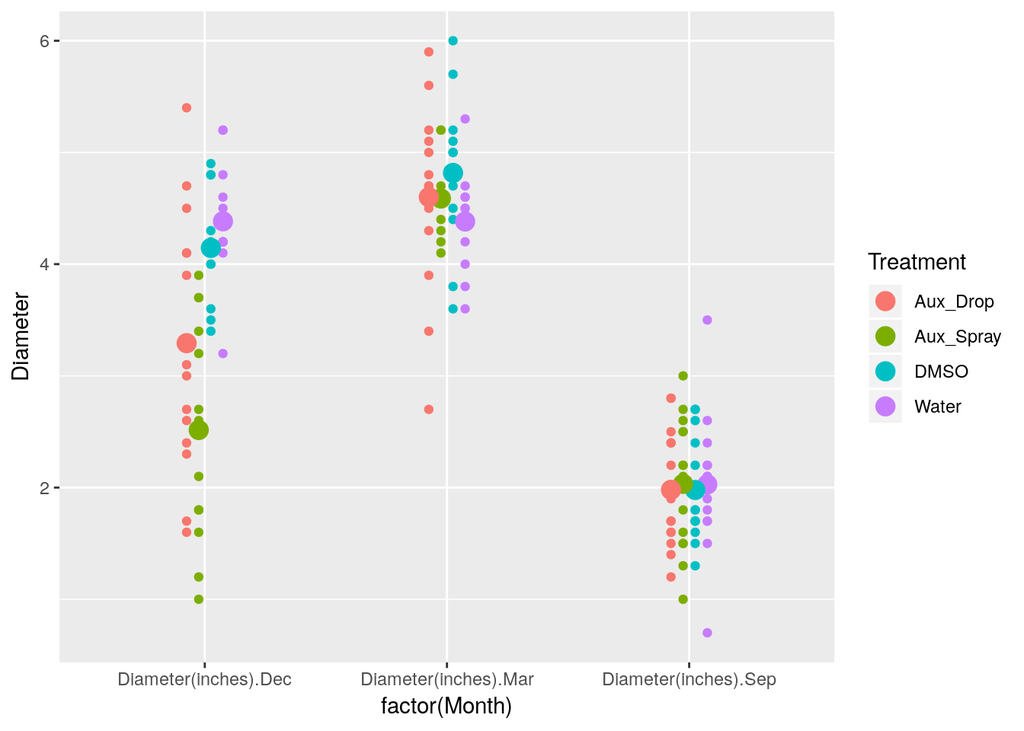

```r
gatheredDiameterAndTreatmentData  %>%
  subset(Diameter != "NA") %>%
  ggplot(aes(x = factor(Month), y = Diameter)) +
  geom_point(aes(colour = Treatment), na.rm = TRUE,
             position = position_dodge(width = 0.2)) +
  geom_point(data = subMeansDiameter, size = 4, aes(colour = Treatment),
             na.rm = TRUE, position = position_dodge(width = 0.2))
```

**The above plot can be customized and improved by :**  
1) arranging the plot by factors (i.e increasing order of Month (“Sept” 2017 at the beginning)  
2) and by adding custom color code to represent each treatment

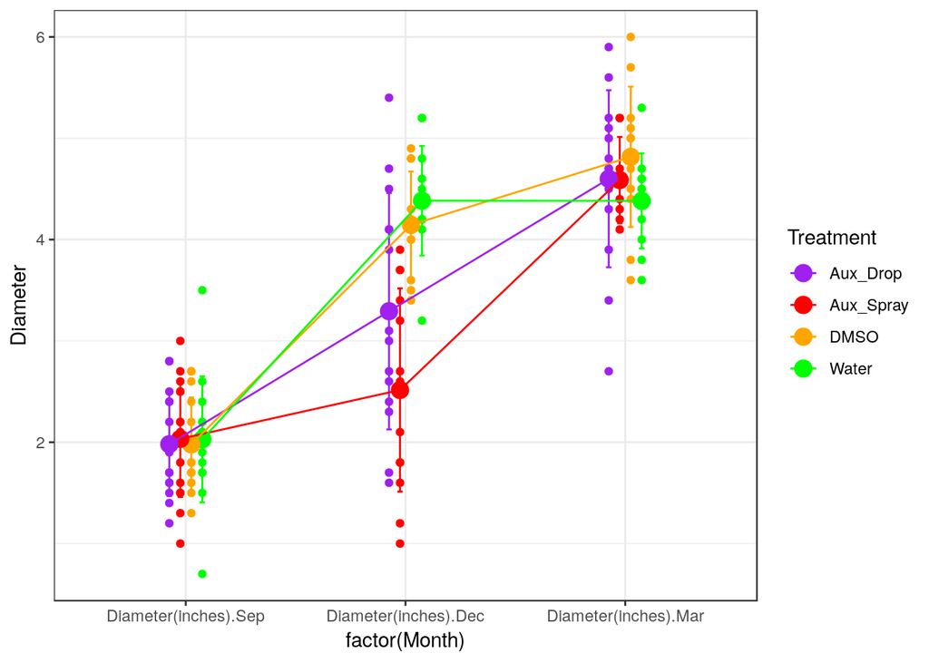

```r
gatheredDiameterAndTreatmentData  %>%
  subset(Diameter != "NA") %>%
  ggplot(aes(x = factor(Month), y = Diameter)) +
  geom_point(aes(colour = Treatment), na.rm = TRUE,
             position = position_dodge(width = 0.2)) +
  geom_point(data = subMeansDiameter, size = 4, aes(colour = Treatment),
             na.rm = TRUE, position = position_dodge(width = 0.2)) +

  theme_bw() + # remove background

  # add custom color to the "Treatment" levels
  scale_colour_manual(
    values = c("Aux_Drop" = "Purple", "Aux_Spray" = "Red",
               "DMSO" = "Orange", "Water" = "Green")) +

  # rearrange the x-axis
  scale_x_discrete(limits=c(
      "Diameter(inches).Sep", "Diameter(inches).Dec",
      "Diameter(inches).Mar")) +

  # add an error bar for each "sub-means"
  geom_errorbar(data = subMeansDiameter, aes(
    colour = Treatment, ymin=Diameter-SEdiam, ymax=Diameter+SEdiam),
    position = position_dodge(width = 0.2), width=.1, size = 0.5) +

  # to connect the "subMeans - Diameter" values across time points
  geom_line(data = subMeansDiameter, aes(
    x = Month, y = Diameter, group = Treatment, colour = Treatment),
    position = position_dodge(width = 0.2))
```

```r
  # ** to do : add
    # number of samples in each "Treatment, by Months" - as ticks on x-axis
    # type "mean" and "SE" values, after that sample size value

  # ** to do : Make plot by each "TreatmentLevel" for each time period (month)
```

#### 06 - B) Now, make similar plots for “lateral shoot rating”

**Plot - Changes in “lateral shoot development” across time (by Treatment)**

##### 06 - B (i) : Run some data preparation before plotting

**Make a new dataframe containing data only on (lateral shoot rating) by “Treatment” for each time points**

```r
laterShootColNames = unique(grep(paste(c("Lat_Shoot"), collapse="|"),
                               colnames(merged.Sep.Dec.Mar), value=TRUE))
laterShootColNames
```

```
## [1] "Lat_Shoot_R.Sep" "Lat_Shoot_R.Dec" "Lat_Shoot_R.Mar"
```

```r
# for that we make a new dataframe with diameter (by each time) and treatment
lateralShootAndTreatmentData = subset(
  merged.Sep.Dec.Mar, select = c(laterShootColNames, "Treatment"))
head(lateralShootAndTreatmentData)
```

```
##   Lat_Shoot_R.Sep Lat_Shoot_R.Dec Lat_Shoot_R.Mar Treatment
## 1               0              NA              NA  Aux_Drop
## 2               0               2               3 Aux_Spray
## 3               0              NA              NA      DMSO
## 4               0               2               3     Water
## 5               1               3               3  Aux_Drop
## 6               0               3               3 Aux_Spray
```

```r
## now, reshape the data
gatheredLateralShootAndTreatmentData =
  lateralShootAndTreatmentData %>%  gather(Month, LateralShootR, -Treatment)
head(gatheredLateralShootAndTreatmentData)
```

```
##   Treatment           Month LateralShootR
## 1  Aux_Drop Lat_Shoot_R.Sep             0
## 2 Aux_Spray Lat_Shoot_R.Sep             0
## 3      DMSO Lat_Shoot_R.Sep             0
## 4     Water Lat_Shoot_R.Sep             0
## 5  Aux_Drop Lat_Shoot_R.Sep             1
## 6 Aux_Spray Lat_Shoot_R.Sep             0
```

```r
# Update the datatypes of columns named "LateralShootR"
gatheredLateralShootAndTreatmentData[c("LateralShootR")] <-
  as.double(gatheredLateralShootAndTreatmentData$LateralShootR)
```

```r
# Calculate "sub-mean" (by "Treatment", for each "Month")
subMeansLSR = aggregate(gatheredLateralShootAndTreatmentData$LateralShootR,
  by=list(Treatment = gatheredLateralShootAndTreatmentData$Treatment,
          Month = gatheredLateralShootAndTreatmentData$Month), FUN = mean, na.rm=TRUE)

head(subMeansLSR)
```

```
##   Treatment           Month        x
## 1  Aux_Drop Lat_Shoot_R.Dec 1.923077
## 2 Aux_Spray Lat_Shoot_R.Dec 2.000000
## 3      DMSO Lat_Shoot_R.Dec 2.000000
## 4     Water Lat_Shoot_R.Dec 1.833333
## 5  Aux_Drop Lat_Shoot_R.Mar 2.923077
## 6 Aux_Spray Lat_Shoot_R.Mar 3.125000
```

```r
# the above "aggregate" method puts new values as "x". Change it to "LateralShootR"
colnames(subMeansLSR)[colnames(subMeansLSR)=="x"] <- "LateralShootR"
subMeansLSR
```

```
##    Treatment           Month LateralShootR
## 1   Aux_Drop Lat_Shoot_R.Dec     1.9230769
## 2  Aux_Spray Lat_Shoot_R.Dec     2.0000000
## 3       DMSO Lat_Shoot_R.Dec     2.0000000
## 4      Water Lat_Shoot_R.Dec     1.8333333
## 5   Aux_Drop Lat_Shoot_R.Mar     2.9230769
## 6  Aux_Spray Lat_Shoot_R.Mar     3.1250000
## 7       DMSO Lat_Shoot_R.Mar     2.4166667
## 8      Water Lat_Shoot_R.Mar     2.7272727
## 9   Aux_Drop Lat_Shoot_R.Sep     0.4000000
## 10 Aux_Spray Lat_Shoot_R.Sep     0.2666667
## 11      DMSO Lat_Shoot_R.Sep     0.2857143
## 12     Water Lat_Shoot_R.Sep     0.3571429
```

```r
## Similarly compute "standard error"
# Calculate "sub-mean" value (by "Treatment", by "Month")
subSErrLSR = aggregate(
  as.double(unlist(gatheredLateralShootAndTreatmentData$LateralShootR)),
  by=list(Treatment = gatheredLateralShootAndTreatmentData$Treatment,
          Month = gatheredLateralShootAndTreatmentData$Month), FUN = sd , na.rm=TRUE)

# Change column name "x" to "SE"
colnames(subSErrLSR)[colnames(subSErrLSR)=="x"] <- "SElsr"
head(subSErrLSR)
```

```
##   Treatment           Month     SElsr
## 1  Aux_Drop Lat_Shoot_R.Dec 0.4935481
## 2 Aux_Spray Lat_Shoot_R.Dec 0.7385489
## 3      DMSO Lat_Shoot_R.Dec 0.0000000
## 4     Water Lat_Shoot_R.Dec 0.3892495
## 5  Aux_Drop Lat_Shoot_R.Mar 0.8623165
## 6 Aux_Spray Lat_Shoot_R.Mar 0.3535534
```

```r
## now, bind the "subMeansLSR" with "subSErrLSR"
subMeansLSR = Reduce(function(x, y)
  merge(x, y, by=c("Treatment", "Month"),
        all = TRUE), list(subMeansLSR, subSErrLSR))

head(subMeansLSR)
```

```
##   Treatment           Month LateralShootR     SElsr
## 1  Aux_Drop Lat_Shoot_R.Dec     1.9230769 0.4935481
## 2  Aux_Drop Lat_Shoot_R.Mar     2.9230769 0.8623165
## 3  Aux_Drop Lat_Shoot_R.Sep     0.4000000 0.5070926
## 4 Aux_Spray Lat_Shoot_R.Dec     2.0000000 0.7385489
## 5 Aux_Spray Lat_Shoot_R.Mar     3.1250000 0.3535534
## 6 Aux_Spray Lat_Shoot_R.Sep     0.2666667 0.4577377
```

##### 06 - B (ii) : Plot variation in “lateral shoot rating” by “Treatment” for each time points

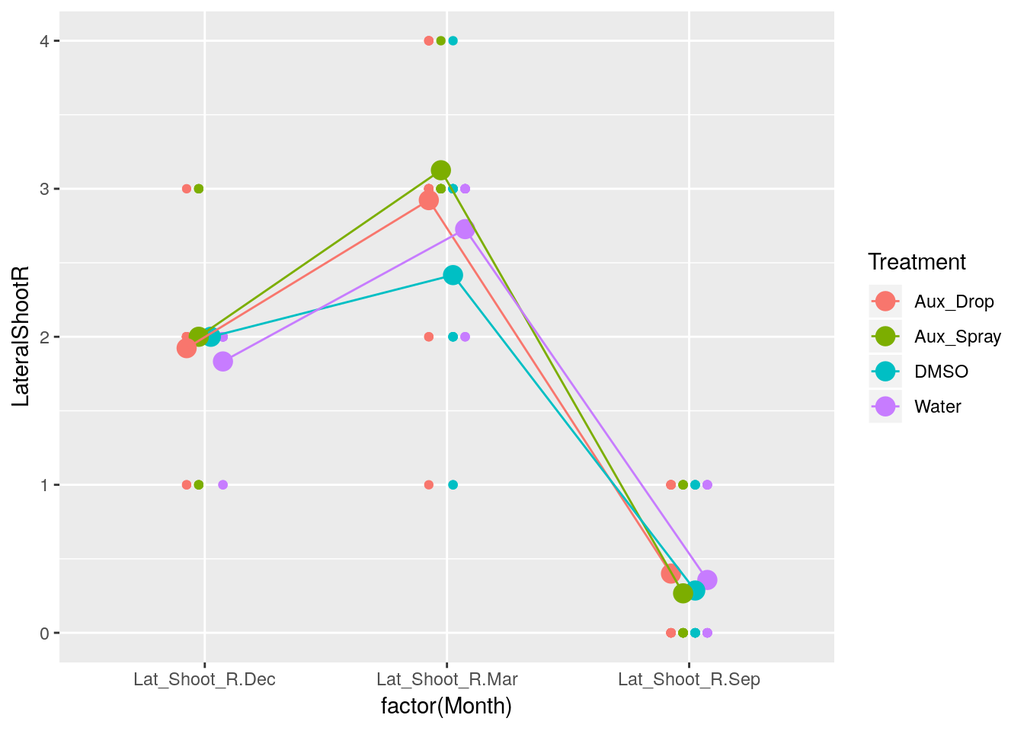

```r
gatheredLateralShootAndTreatmentData  %>%
  subset(LateralShootR != "NA") %>%
  ggplot(aes(x = factor(Month), y = LateralShootR)) +
  geom_point(aes(colour = Treatment), na.rm = TRUE,
             position = position_dodge(width = 0.2)) +
  geom_point(data = subMeansLSR, size = 4, aes(colour = Treatment),
             na.rm = TRUE, position = position_dodge(width = 0.2)) +
  geom_line(data = subMeansLSR, aes(
    x = Month, y = LateralShootR, group = Treatment, colour = Treatment),
    position = position_dodge(width = 0.2))
```

**The above plot can be customized and improved to :**  
1) arrange the plot by factors (i.e Month, with “Sept” at the beginning)  
2) add custom color code to the treatment

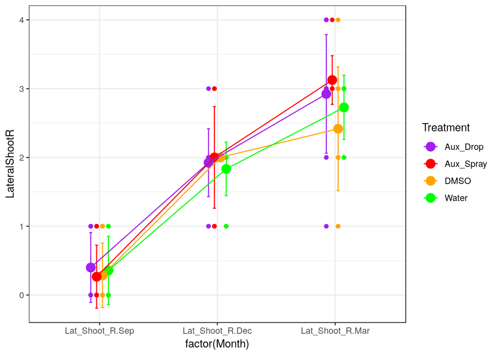

```r
gatheredLateralShootAndTreatmentData  %>%
  subset(LateralShootR != "NA") %>%
  ggplot(aes(x = factor(Month), y = LateralShootR)) +
  geom_point(aes(colour = Treatment), na.rm = TRUE,
             position = position_dodge(width = 0.2)) +
  geom_point(data = subMeansLSR, size = 4, aes(colour = Treatment),
             na.rm = TRUE, position = position_dodge(width = 0.2)) +

  theme_bw() + # remove background

  # add custome color to the "Treatment" levels
  scale_colour_manual(
    values = c("Aux_Drop" = "Purple", "Aux_Spray" = "Red",
               "DMSO" = "Orange", "Water" = "Green")) +

  # rearrange the x-axis
  scale_x_discrete(limits=c(
    "Lat_Shoot_R.Sep", "Lat_Shoot_R.Dec",
    "Lat_Shoot_R.Mar")) +

  # add an error bar for each "sub-means"
  geom_errorbar(data = subMeansLSR, aes(
    colour = Treatment, ymin=LateralShootR-SElsr, ymax=LateralShootR+SElsr),
    position = position_dodge(width = 0.2), width=.1, size = 0.5) +

  # to connect the "subMeans - Diameter" values across time points
  geom_line(data = subMeansLSR, aes(
    x = Month, y = LateralShootR, group = Treatment, colour = Treatment),
    position = position_dodge(width = 0.2))
```

### Step 07 : Statistical tests

```r
# ... continuing  ....
```

#### Step 07 - A : Linear regression model **Some preliminary tests**

```r
# modeling the effects of treatment
####
print('hello')
```

```
## [1] "hello"
```

```r
colnames(merged.Sep.Dec.Mar)
```

```
##  [1] "Plant_ID"             "Population"           "Family"
##  [4] "TreatmentLevel"       "Treatment"            "Diameter(inches).Sep"
##  [7] "Lat_Shoot_R.Sep"      "Inflorescence.Sep"    "Leaf_Shape.Sep"
## [10] "Trichomes_int.Sep"    "Bolting.Sep"          "Flowering.Sep"
## [13] "Diameter(inches).Dec" "Lat_Shoot_R.Dec"      "Inflorescence.Dec"
## [16] "Leaf_Shape.Dec"       "Trichomes_int.Dec"    "Bolting.Dec"
## [19] "Flowering.Dec"        "Diameter(inches).Mar" "Lat_Shoot_R.Mar"
## [22] "Inflorescence.Mar"    "Leaf_Shape.Mar"       "Trichomes_int.Mar"
## [25] "Bolting.Mar"          "Flowering.Mar"
```

```r
# relevel factors to include "Control" as the reference level
merged.Sep.Dec.Mar = within(
  merged.Sep.Dec.Mar,
  TreatmentLevel <- relevel(TreatmentLevel, ref = "Control"))

merged.Sep.Dec.Mar = within(
  merged.Sep.Dec.Mar,
  Treatment <- relevel(Treatment, ref = "Water"))

plantDiamSep <- lm(`Diameter(inches).Sep` ~ TreatmentLevel, merged.Sep.Dec.Mar)
summary(plantDiamSep)
```

```
##
## Call:
## lm(formula = `Diameter(inches).Sep` ~ TreatmentLevel, data = merged.Sep.Dec.Mar)
##
## Residuals:
##      Min       1Q   Median       3Q      Max
## -1.30357 -0.37935 -0.00667  0.39565  1.49643
##
## Coefficients:
##                     Estimate Std. Error t value Pr(>|t|)
## (Intercept)         2.003571   0.101357  19.768   <2e-16 ***
## TreatmentLevelAuxin 0.003095   0.140931   0.022    0.983
## ---
## Signif. codes:  0 '***' 0.001 '**' 0.01 '*' 0.05 '.' 0.1 ' ' 1
##
## Residual standard error: 0.5363 on 56 degrees of freedom
##   (1 observation deleted due to missingness)
## Multiple R-squared:  8.614e-06,  Adjusted R-squared:  -0.01785
## F-statistic: 0.0004824 on 1 and 56 DF,  p-value: 0.9826
```

```r
plantDiamSep01 <- lm(`Diameter(inches).Sep` ~ Treatment, merged.Sep.Dec.Mar)
summary(plantDiamSep01)
```

```
##
## Call:
## lm(formula = `Diameter(inches).Sep` ~ Treatment, data = merged.Sep.Dec.Mar)
##
## Residuals:
##      Min       1Q   Median       3Q      Max
## -1.32857 -0.36607 -0.03095  0.42000  1.47143
##
## Coefficients:
##                     Estimate Std. Error t value Pr(>|t|)
## (Intercept)         2.028571   0.145794  13.914   <2e-16 ***
## TreatmentAux_Drop  -0.048571   0.202718  -0.240    0.812
## TreatmentAux_Spray  0.004762   0.202718   0.023    0.981
## TreatmentDMSO      -0.050000   0.206184  -0.243    0.809
## ---
## Signif. codes:  0 '***' 0.001 '**' 0.01 '*' 0.05 '.' 0.1 ' ' 1
##
## Residual standard error: 0.5455 on 54 degrees of freedom
##   (1 observation deleted due to missingness)
## Multiple R-squared:  0.002419,   Adjusted R-squared:  -0.053
## F-statistic: 0.04365 on 3 and 54 DF,  p-value: 0.9877
```

```r
## 07 - A (i):
# Testing if there was family level effects on diameter before any treatment started.
plantDiamSepFam <- lm(`Diameter(inches).Sep` ~ TreatmentLevel/Family, merged.Sep.Dec.Mar)
summary(plantDiamSepFam)
```

```
##
## Call:
## lm(formula = `Diameter(inches).Sep` ~ TreatmentLevel/Family,
##     data = merged.Sep.Dec.Mar)
##
## Residuals:
##    Min     1Q Median     3Q    Max
## -0.975 -0.350  0.000  0.350  1.129
##
## Coefficients: (2 not defined because of singularities)
##                                Estimate Std. Error t value Pr(>|t|)
## (Intercept)                     2.37143    0.19445  12.195 2.18e-15 ***
## TreatmentLevelAuxin            -0.17143    0.26627  -0.644  0.52319
## TreatmentLevelControl:Family9  -0.32143    0.41250  -0.779  0.44022
## TreatmentLevelAuxin:Family9     0.60000    0.54568   1.100  0.27780
## TreatmentLevelControl:Family11       NA         NA      NA       NA
## TreatmentLevelAuxin:Family11   -0.40000    0.54568  -0.733  0.46761
## TreatmentLevelControl:Family13 -0.13143    0.30125  -0.436  0.66487
## TreatmentLevelAuxin:Family13   -0.22500    0.31505  -0.714  0.47907
## TreatmentLevelControl:Family14       NA         NA      NA       NA
## TreatmentLevelAuxin:Family14   -0.55000    0.40673  -1.352  0.18353
## TreatmentLevelControl:Family16 -0.43810    0.35502  -1.234  0.22407
## TreatmentLevelAuxin:Family16   -0.40000    0.40673  -0.983  0.33101
## TreatmentLevelControl:Family17 -0.37143    0.41250  -0.900  0.37302
## TreatmentLevelAuxin:Family17    0.06667    0.34830   0.191  0.84913
## TreatmentLevelControl:Family20 -0.92143    0.32246  -2.857  0.00662 **
## TreatmentLevelAuxin:Family20   -0.63333    0.34830  -1.818  0.07615 .
## TreatmentLevelControl:Family21 -0.65143    0.30125  -2.162  0.03633 *
## TreatmentLevelAuxin:Family21   -0.25000    0.27785  -0.900  0.37337
## ---
## Signif. codes:  0 '***' 0.001 '**' 0.01 '*' 0.05 '.' 0.1 ' ' 1
##
## Residual standard error: 0.5145 on 42 degrees of freedom
##   (1 observation deleted due to missingness)
## Multiple R-squared:  0.3099, Adjusted R-squared:  0.06341
## F-statistic: 1.257 on 15 and 42 DF,  p-value: 0.271
```

```r
plantDiamSepFam01 <- lm(`Diameter(inches).Sep` ~ Treatment/Family, merged.Sep.Dec.Mar)
summary(plantDiamSepFam01)
```

```
##
## Call:
## lm(formula = `Diameter(inches).Sep` ~ Treatment/Family, data = merged.Sep.Dec.Mar)
##
## Residuals:
##     Min      1Q  Median      3Q     Max
## -0.8333 -0.2208  0.0000  0.1667  0.9667
##
## Coefficients: (6 not defined because of singularities)
##                             Estimate Std. Error t value Pr(>|t|)
## (Intercept)                  2.53333    0.29453   8.601  2.4e-09 ***
## TreatmentAux_Drop           -0.70833    0.38962  -1.818   0.0798 .
## TreatmentAux_Spray           0.04167    0.38962   0.107   0.9156
## TreatmentDMSO               -0.28333    0.38962  -0.727   0.4731
## TreatmentWater:Family9      -0.83333    0.58905  -1.415   0.1682
## TreatmentAux_Drop:Family9    0.97500    0.57035   1.709   0.0984 .
## TreatmentAux_Spray:Family9        NA         NA      NA       NA
## TreatmentDMSO:Family9        0.15000    0.57035   0.263   0.7945
## TreatmentWater:Family11           NA         NA      NA       NA
## TreatmentAux_Drop:Family11        NA         NA      NA       NA
## TreatmentAux_Spray:Family11 -0.77500    0.57035  -1.359   0.1851
## TreatmentDMSO:Family11            NA         NA      NA       NA
## TreatmentWater:Family13     -0.23333    0.46569  -0.501   0.6203
## TreatmentAux_Drop:Family13   0.62500    0.44179   1.415   0.1682
## TreatmentAux_Spray:Family13 -1.07500    0.44179  -2.433   0.0216 *
## TreatmentDMSO:Family13      -0.05000    0.38962  -0.128   0.8988
## TreatmentWater:Family14           NA         NA      NA       NA
## TreatmentAux_Drop:Family14  -0.12500    0.57035  -0.219   0.8281
## TreatmentAux_Spray:Family14 -0.97500    0.57035  -1.709   0.0984 .
## TreatmentDMSO:Family14            NA         NA      NA       NA
## TreatmentWater:Family16     -0.53333    0.46569  -1.145   0.2618
## TreatmentAux_Drop:Family16  -0.42500    0.57035  -0.745   0.4624
## TreatmentAux_Spray:Family16 -0.37500    0.57035  -0.657   0.5162
## TreatmentDMSO:Family16      -0.45000    0.57035  -0.789   0.4367
## TreatmentWater:Family17     -0.33333    0.58905  -0.566   0.5760
## TreatmentAux_Drop:Family17   0.97500    0.57035   1.709   0.0984 .
## TreatmentAux_Spray:Family17 -0.57500    0.44179  -1.302   0.2037
## TreatmentDMSO:Family17      -0.45000    0.57035  -0.789   0.4367
## TreatmentWater:Family20     -1.28333    0.46569  -2.756   0.0102 *
## TreatmentAux_Drop:Family20  -0.22500    0.44179  -0.509   0.6145
## TreatmentAux_Spray:Family20 -1.07500    0.57035  -1.885   0.0699 .
## TreatmentDMSO:Family20      -0.60000    0.44179  -1.358   0.1853
## TreatmentWater:Family21     -0.60000    0.41652  -1.440   0.1608
## TreatmentAux_Drop:Family21   0.04167    0.38962   0.107   0.9156
## TreatmentAux_Spray:Family21 -0.54167    0.38962  -1.390   0.1754
## TreatmentDMSO:Family21      -0.85000    0.44179  -1.924   0.0646 .
## ---
## Signif. codes:  0 '***' 0.001 '**' 0.01 '*' 0.05 '.' 0.1 ' ' 1
##
## Residual standard error: 0.5101 on 28 degrees of freedom
##   (1 observation deleted due to missingness)
## Multiple R-squared:  0.5476, Adjusted R-squared:  0.07914
## F-statistic: 1.169 on 29 and 28 DF,  p-value: 0.3408
```

```r
## Result: We can see that there was no significant differences in diameter before the
   # treatment was started for any "TreatmentLevel : Control vs. Auxin".
## Result 01: We can see that there was no significant differences in diameter before the
   # treatment was started for any "Treatment : Control vs. Auxin". "Treatment : Water vs. DMSO vs. Auxin Spray vs. Auxin droplet".

## Result (with Family as covariate):
  # Family 20 and 21 had some discrepancies in initial diameter before the treatment started.


## 07 - A (ii):
## Now, check if diameter were different in the month of december
plantDiamDec <- lm(`Diameter(inches).Dec` ~ TreatmentLevel, merged.Sep.Dec.Mar)
summary(plantDiamDec)
```

```
##
## Call:
## lm(formula = `Diameter(inches).Dec` ~ TreatmentLevel, data = merged.Sep.Dec.Mar)
##
## Residuals:
##      Min       1Q   Median       3Q      Max
## -1.91852 -0.59352 -0.06957  0.53043  2.48148
##
## Coefficients:
##                     Estimate Std. Error t value Pr(>|t|)
## (Intercept)           4.2696     0.1907  22.389  < 2e-16 ***
## TreatmentLevelAuxin  -1.3510     0.2595  -5.206 3.98e-06 ***
## ---
## Signif. codes:  0 '***' 0.001 '**' 0.01 '*' 0.05 '.' 0.1 ' ' 1
##
## Residual standard error: 0.9146 on 48 degrees of freedom
##   (9 observations deleted due to missingness)
## Multiple R-squared:  0.3609, Adjusted R-squared:  0.3476
## F-statistic:  27.1 on 1 and 48 DF,  p-value: 3.982e-06
```